# Risk Factor Analysis

## Outcome Variable

**Outcome Variable:** ever_sstunted

## Predictor Variables

**Intervention Variable:** meducyrs

**Adjustment Set:**

- arm
- W_mage
- feducyrs
- hhwealth_quart
- W_mhtcm
- W_mwtkg
- W_mbmi
- W_gagebrth
- W_birthwt
- W_birthlen
- single
- W_nrooms
- impsan
- delta_W_mage
- delta_feducyrs
- delta_hhwealth_quart
- delta_W_mhtcm
- delta_W_mwtkg
- delta_W_mbmi
- delta_W_gagebrth
- delta_W_birthwt
- delta_W_birthlen
- delta_single
- delta_W_nrooms
- delta_impsan

## Stratifying Variables

The analysis was stratified on these variable(s):

- agecat
- studyid
- country

## Data Summary

| agecat | studyid | country | meducyrs | ever_sstunted | n_cell | n |
| --- | --- | --- | --- | --- | --- | --- |
| 0-24 months | CMC-V-BCS-2002 | INDIA | High | 0 | 65 | 373 |
| 0-24 months | CMC-V-BCS-2002 | INDIA | High | 1 | 93 | 373 |
| 0-24 months | CMC-V-BCS-2002 | INDIA | Low | 0 | 37 | 373 |
| 0-24 months | CMC-V-BCS-2002 | INDIA | Low | 1 | 69 | 373 |
| 0-24 months | CMC-V-BCS-2002 | INDIA | Medium | 0 | 34 | 373 |
| 0-24 months | CMC-V-BCS-2002 | INDIA | Medium | 1 | 75 | 373 |
| 0-24 months | COHORTS | GUATEMALA | High | 0 | 161 | 1341 |
| 0-24 months | COHORTS | GUATEMALA | High | 1 | 124 | 1341 |
| 0-24 months | COHORTS | GUATEMALA | Low | 0 | 326 | 1341 |
| 0-24 months | COHORTS | GUATEMALA | Low | 1 | 310 | 1341 |
| 0-24 months | COHORTS | GUATEMALA | Medium | 0 | 232 | 1341 |
| 0-24 months | COHORTS | GUATEMALA | Medium | 1 | 188 | 1341 |
| 0-24 months | COHORTS | INDIA | High | 0 | 761 | 5852 |
| 0-24 months | COHORTS | INDIA | High | 1 | 32 | 5852 |
| 0-24 months | COHORTS | INDIA | Low | 0 | 1530 | 5852 |
| 0-24 months | COHORTS | INDIA | Low | 1 | 426 | 5852 |
| 0-24 months | COHORTS | INDIA | Medium | 0 | 2788 | 5852 |
| 0-24 months | COHORTS | INDIA | Medium | 1 | 315 | 5852 |
| 0-24 months | COHORTS | PHILIPPINES | High | 0 | 885 | 3058 |
| 0-24 months | COHORTS | PHILIPPINES | High | 1 | 288 | 3058 |
| 0-24 months | COHORTS | PHILIPPINES | Low | 0 | 481 | 3058 |
| 0-24 months | COHORTS | PHILIPPINES | Low | 1 | 422 | 3058 |
| 0-24 months | COHORTS | PHILIPPINES | Medium | 0 | 603 | 3058 |
| 0-24 months | COHORTS | PHILIPPINES | Medium | 1 | 379 | 3058 |
| 0-24 months | EE | PAKISTAN | High | 0 | 8 | 376 |
| 0-24 months | EE | PAKISTAN | High | 1 | 7 | 376 |
| 0-24 months | EE | PAKISTAN | Low | 0 | 122 | 376 |
| 0-24 months | EE | PAKISTAN | Low | 1 | 206 | 376 |
| 0-24 months | EE | PAKISTAN | Medium | 0 | 20 | 376 |
| 0-24 months | EE | PAKISTAN | Medium | 1 | 13 | 376 |

[output cut: 126 more lines]

The following strata were considered:

- agecat: 0-24 months, studyid: CMC-V-BCS-2002, country: INDIA
- agecat: 0-24 months, studyid: COHORTS, country: GUATEMALA
- agecat: 0-24 months, studyid: COHORTS, country: INDIA
- agecat: 0-24 months, studyid: COHORTS, country: PHILIPPINES
- agecat: 0-24 months, studyid: EE, country: PAKISTAN
- agecat: 0-24 months, studyid: GMS-Nepal, country: NEPAL
- agecat: 0-24 months, studyid: Guatemala BSC, country: GUATEMALA
- agecat: 0-24 months, studyid: IRC, country: INDIA
- agecat: 0-24 months, studyid: JiVitA-3, country: BANGLADESH
- agecat: 0-24 months, studyid: JiVitA-4, country: BANGLADESH
- agecat: 0-24 months, studyid: LCNI-5, country: MALAWI
- agecat: 0-24 months, studyid: MAL-ED, country: BANGLADESH
- agecat: 0-24 months, studyid: MAL-ED, country: BRAZIL
- agecat: 0-24 months, studyid: MAL-ED, country: INDIA
- agecat: 0-24 months, studyid: MAL-ED, country: NEPAL
- agecat: 0-24 months, studyid: MAL-ED, country: PERU
- agecat: 0-24 months, studyid: MAL-ED, country: SOUTH AFRICA
- agecat: 0-24 months, studyid: MAL-ED, country: TANZANIA, UNITED REPUBLIC OF
- agecat: 0-24 months, studyid: NIH-Birth, country: BANGLADESH
- agecat: 0-24 months, studyid: NIH-Crypto, country: BANGLADESH
- agecat: 0-24 months, studyid: PROBIT, country: BELARUS
- agecat: 0-24 months, studyid: PROVIDE, country: BANGLADESH
- agecat: 0-24 months, studyid: SAS-CompFeed, country: INDIA
- agecat: 0-24 months, studyid: SAS-FoodSuppl, country: INDIA
- agecat: 0-24 months, studyid: TanzaniaChild2, country: TANZANIA, UNITED REPUBLIC OF
- agecat: 0-24 months, studyid: ZVITAMBO, country: ZIMBABWE

### Dropped Strata

Some strata were dropped due to rare outcomes:

- agecat: 0-24 months, studyid: MAL-ED, country: BRAZIL

## Methods Detail

We're interested in the causal parameters $E[Y_a]$ for all values of $a \in \mathcal{A}$. These parameters represent the mean outcome if, possibly contrary to fact, we intervened to set all units to have $A=a$. Under the randomization and positivity assumptions, these are identified by the statistical parameters $\psi_a=E_W[E_{Y|A,W}(Y|A=a,W)]$. In addition, we're interested in the mean of $Y$, $E[Y]$ under no intervention (the observed mean). We will estimate these parameters by using SuperLearner to fit the relevant likelihood factors -- $E_{Y|A,W}(Y|A=a,W)$ and $p(A=a|W)$, and then updating our likelihood fit using a joint TMLE.

For unadjusted analyses ($W=\{\}$), initial likelihoods were estimated using Lrnr_glm to estimate the simple $E(Y|A)$ and Lrnr_mean to estimate $p(A)$. For adjusted analyses, a small library containing Lrnr_glmnet, Lrnr_xgboost, and Lrnr_mean was used.

Having estimated these parameters, we will then use the delta method to estimate relative risks and attributable risks relative to a prespecified baseline level of $A$.

# Results Detail

## Results Plots

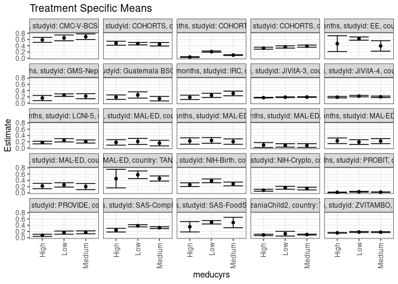

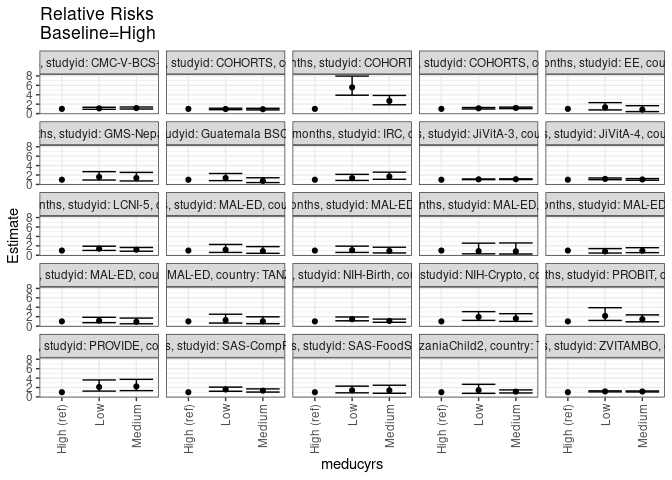

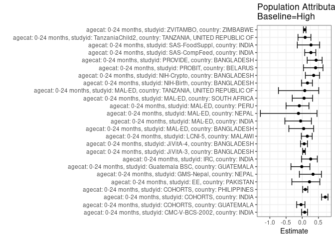

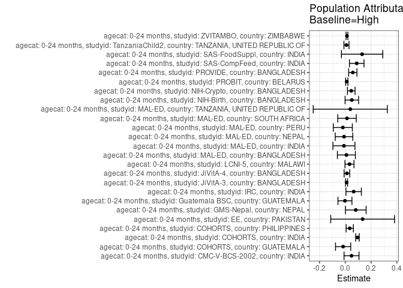

## Results Table

### Parameter: TSM

| agecat | studyid | country | intervention_level | baseline_level | estimate | ci_lower | ci_upper |
| --- | --- | --- | --- | --- | --- | --- | --- |
| 0-24 months | CMC-V-BCS-2002 | INDIA | High | NA | 0.5873213 | 0.5098300 | 0.6648125 |
| 0-24 months | CMC-V-BCS-2002 | INDIA | Low | NA | 0.6509278 | 0.5592001 | 0.7426555 |
| 0-24 months | CMC-V-BCS-2002 | INDIA | Medium | NA | 0.6887935 | 0.6005241 | 0.7770628 |
| 0-24 months | COHORTS | GUATEMALA | High | NA | 0.4808950 | 0.4164922 | 0.5452978 |
| 0-24 months | COHORTS | GUATEMALA | Low | NA | 0.4674964 | 0.4275732 | 0.5074197 |
| 0-24 months | COHORTS | GUATEMALA | Medium | NA | 0.4483259 | 0.3919434 | 0.5047085 |
| 0-24 months | COHORTS | INDIA | High | NA | 0.0379202 | 0.0248942 | 0.0509462 |
| 0-24 months | COHORTS | INDIA | Low | NA | 0.2114608 | 0.1919864 | 0.2309352 |
| 0-24 months | COHORTS | INDIA | Medium | NA | 0.1020604 | 0.0911028 | 0.1130180 |
| 0-24 months | COHORTS | PHILIPPINES | High | NA | 0.3217006 | 0.2897575 | 0.3536437 |
| 0-24 months | COHORTS | PHILIPPINES | Low | NA | 0.3610741 | 0.3249999 | 0.3971483 |
| 0-24 months | COHORTS | PHILIPPINES | Medium | NA | 0.3879445 | 0.3539450 | 0.4219439 |
| 0-24 months | EE | PAKISTAN | High | NA | 0.4666667 | 0.2138629 | 0.7194704 |
| 0-24 months | EE | PAKISTAN | Low | NA | 0.6280488 | 0.5756732 | 0.6804244 |
| 0-24 months | EE | PAKISTAN | Medium | NA | 0.3939394 | 0.2270064 | 0.5608724 |
| 0-24 months | GMS-Nepal | NEPAL | High | NA | 0.1619798 | 0.0792680 | 0.2446915 |
| 0-24 months | GMS-Nepal | NEPAL | Low | NA | 0.2576396 | 0.2181913 | 0.2970879 |
| 0-24 months | GMS-Nepal | NEPAL | Medium | NA | 0.2215779 | 0.1422079 | 0.3009479 |
| 0-24 months | Guatemala BSC | GUATEMALA | High | NA | 0.1908045 | 0.1201463 | 0.2614627 |
| 0-24 months | Guatemala BSC | GUATEMALA | Low | NA | 0.2604067 | 0.1615808 | 0.3592326 |
| 0-24 months | Guatemala BSC | GUATEMALA | Medium | NA | 0.1432470 | 0.0707067 | 0.2157874 |
| 0-24 months | IRC | INDIA | High | NA | 0.1839842 | 0.1145570 | 0.2534114 |
| 0-24 months | IRC | INDIA | Low | NA | 0.2480717 | 0.1801833 | 0.3159601 |
| 0-24 months | IRC | INDIA | Medium | NA | 0.3096332 | 0.2367701 | 0.3824963 |
| 0-24 months | JiVitA-3 | BANGLADESH | High | NA | 0.1745543 | 0.1654334 | 0.1836753 |
| 0-24 months | JiVitA-3 | BANGLADESH | Low | NA | 0.1896169 | 0.1796940 | 0.1995397 |
| 0-24 months | JiVitA-3 | BANGLADESH | Medium | NA | 0.1939451 | 0.1840646 | 0.2038256 |
| 0-24 months | JiVitA-4 | BANGLADESH | High | NA | 0.1912223 | 0.1669799 | 0.2154646 |
| 0-24 months | JiVitA-4 | BANGLADESH | Low | NA | 0.2235884 | 0.2014201 | 0.2457566 |
| 0-24 months | JiVitA-4 | BANGLADESH | Medium | NA | 0.2023638 | 0.1798360 | 0.2248916 |
| 0-24 months | LCNI-5 | MALAWI | High | NA | 0.1752406 | 0.1334543 | 0.2170269 |
| 0-24 months | LCNI-5 | MALAWI | Low | NA | 0.2458733 | 0.1938791 | 0.2978675 |
| 0-24 months | LCNI-5 | MALAWI | Medium | NA | 0.2077646 | 0.1582963 | 0.2572330 |
| 0-24 months | MAL-ED | BANGLADESH | High | NA | 0.1787266 | 0.0916453 | 0.2658078 |
| 0-24 months | MAL-ED | BANGLADESH | Low | NA | 0.2096711 | 0.1129238 | 0.3064184 |
| 0-24 months | MAL-ED | BANGLADESH | Medium | NA | 0.1561978 | 0.0674772 | 0.2449184 |
| 0-24 months | MAL-ED | INDIA | High | NA | 0.2243076 | 0.1224645 | 0.3261507 |
| 0-24 months | MAL-ED | INDIA | Low | NA | 0.2413015 | 0.1496462 | 0.3329567 |
| 0-24 months | MAL-ED | INDIA | Medium | NA | 0.2057318 | 0.1192940 | 0.2921697 |
| 0-24 months | MAL-ED | NEPAL | High | NA | 0.0943396 | 0.0154705 | 0.1732088 |
| 0-24 months | MAL-ED | NEPAL | Low | NA | 0.0833333 | 0.0279225 | 0.1387442 |
| 0-24 months | MAL-ED | NEPAL | Medium | NA | 0.0789474 | 0.0181871 | 0.1397076 |
| 0-24 months | MAL-ED | PERU | High | NA | 0.2312669 | 0.1420964 | 0.3204374 |
| 0-24 months | MAL-ED | PERU | Low | NA | 0.1887394 | 0.1136332 | 0.2638456 |
| 0-24 months | MAL-ED | PERU | Medium | NA | 0.2197816 | 0.1408235 | 0.2987397 |
| 0-24 months | MAL-ED | SOUTH AFRICA | High | NA | 0.2193291 | 0.1347167 | 0.3039415 |
| 0-24 months | MAL-ED | SOUTH AFRICA | Low | NA | 0.2551097 | 0.1850537 | 0.3251657 |
| 0-24 months | MAL-ED | SOUTH AFRICA | Medium | NA | 0.2005445 | 0.1040764 | 0.2970126 |
| 0-24 months | MAL-ED | TANZANIA, UNITED REPUBLIC OF | High | NA | 0.4545455 | 0.1596129 | 0.7494780 |
| 0-24 months | MAL-ED | TANZANIA, UNITED REPUBLIC OF | Low | NA | 0.5781250 | 0.4568521 | 0.6993979 |
| 0-24 months | MAL-ED | TANZANIA, UNITED REPUBLIC OF | Medium | NA | 0.4577465 | 0.3756129 | 0.5398800 |
| 0-24 months | NIH-Birth | BANGLADESH | High | NA | 0.2611389 | 0.2003615 | 0.3219164 |
| 0-24 months | NIH-Birth | BANGLADESH | Low | NA | 0.3853510 | 0.3259509 | 0.4447511 |
| 0-24 months | NIH-Birth | BANGLADESH | Medium | NA | 0.2856787 | 0.2257602 | 0.3455973 |
| 0-24 months | NIH-Crypto | BANGLADESH | High | NA | 0.0845888 | 0.0525258 | 0.1166517 |
| 0-24 months | NIH-Crypto | BANGLADESH | Low | NA | 0.1632933 | 0.1173198 | 0.2092667 |
| 0-24 months | NIH-Crypto | BANGLADESH | Medium | NA | 0.1372557 | 0.0946776 | 0.1798338 |
| 0-24 months | PROBIT | BELARUS | High | NA | 0.0162501 | 0.0072971 | 0.0252030 |
| 0-24 months | PROBIT | BELARUS | Low | NA | 0.0351647 | 0.0225599 | 0.0477694 |
| 0-24 months | PROBIT | BELARUS | Medium | NA | 0.0239419 | 0.0171859 | 0.0306979 |
| 0-24 months | PROVIDE | BANGLADESH | High | NA | 0.0776046 | 0.0434313 | 0.1117779 |
| 0-24 months | PROVIDE | BANGLADESH | Low | NA | 0.1639038 | 0.1144523 | 0.2133554 |
| 0-24 months | PROVIDE | BANGLADESH | Medium | NA | 0.1729584 | 0.1265669 | 0.2193500 |
| 0-24 months | SAS-CompFeed | INDIA | High | NA | 0.2421185 | 0.1825406 | 0.3016965 |
| 0-24 months | SAS-CompFeed | INDIA | Low | NA | 0.3824671 | 0.3469110 | 0.4180232 |
| 0-24 months | SAS-CompFeed | INDIA | Medium | NA | 0.3207259 | 0.2911622 | 0.3502896 |
| 0-24 months | SAS-FoodSuppl | INDIA | High | NA | 0.3507191 | 0.1850771 | 0.5163612 |
| 0-24 months | SAS-FoodSuppl | INDIA | Low | NA | 0.4942178 | 0.4396910 | 0.5487446 |
| 0-24 months | SAS-FoodSuppl | INDIA | Medium | NA | 0.4861269 | 0.3215186 | 0.6507352 |
| 0-24 months | TanzaniaChild2 | TANZANIA, UNITED REPUBLIC OF | High | NA | 0.0904385 | 0.0680375 | 0.1128395 |
| 0-24 months | TanzaniaChild2 | TANZANIA, UNITED REPUBLIC OF | Low | NA | 0.1290694 | 0.0545436 | 0.2035951 |
| 0-24 months | TanzaniaChild2 | TANZANIA, UNITED REPUBLIC OF | Medium | NA | 0.1012689 | 0.0868211 | 0.1157167 |
| 0-24 months | ZVITAMBO | ZIMBABWE | High | NA | 0.1553032 | 0.1465301 | 0.1640764 |
| 0-24 months | ZVITAMBO | ZIMBABWE | Low | NA | 0.1820546 | 0.1671031 | 0.1970060 |
| 0-24 months | ZVITAMBO | ZIMBABWE | Medium | NA | 0.1786140 | 0.1657239 | 0.1915041 |

### Parameter: E(Y)

| agecat | studyid | country | intervention_level | baseline_level | estimate | ci_lower | ci_upper |
| --- | --- | --- | --- | --- | --- | --- | --- |
| 0-24 months | CMC-V-BCS-2002 | INDIA | NA | NA | 0.6353887 | 0.5864772 | 0.6843003 |
| 0-24 months | COHORTS | GUATEMALA | NA | NA | 0.4638330 | 0.4371320 | 0.4905339 |
| 0-24 months | COHORTS | INDIA | NA | NA | 0.1320916 | 0.1234158 | 0.1407674 |
| 0-24 months | COHORTS | PHILIPPINES | NA | NA | 0.3561151 | 0.3391405 | 0.3730897 |
| 0-24 months | EE | PAKISTAN | NA | NA | 0.6010638 | 0.5515023 | 0.6506253 |
| 0-24 months | GMS-Nepal | NEPAL | NA | NA | 0.2431655 | 0.2112486 | 0.2750823 |
| 0-24 months | Guatemala BSC | GUATEMALA | NA | NA | 0.1879433 | 0.1422658 | 0.2336207 |
| 0-24 months | IRC | INDIA | NA | NA | 0.2487805 | 0.2068840 | 0.2906770 |
| 0-24 months | JiVitA-3 | BANGLADESH | NA | NA | 0.1846063 | 0.1789984 | 0.1902143 |
| 0-24 months | JiVitA-4 | BANGLADESH | NA | NA | 0.2035431 | 0.1916695 | 0.2154167 |
| 0-24 months | LCNI-5 | MALAWI | NA | NA | 0.2076167 | 0.1797361 | 0.2354973 |
| 0-24 months | MAL-ED | BANGLADESH | NA | NA | 0.1869159 | 0.1345620 | 0.2392698 |
| 0-24 months | MAL-ED | INDIA | NA | NA | 0.2136364 | 0.1593519 | 0.2679208 |
| 0-24 months | MAL-ED | NEPAL | NA | NA | 0.0844444 | 0.0480318 | 0.1208571 |
| 0-24 months | MAL-ED | PERU | NA | NA | 0.2119205 | 0.1657530 | 0.2580880 |
| 0-24 months | MAL-ED | SOUTH AFRICA | NA | NA | 0.2324841 | 0.1856873 | 0.2792809 |
| 0-24 months | MAL-ED | TANZANIA, UNITED REPUBLIC OF | NA | NA | 0.4930876 | 0.4264146 | 0.5597605 |
| 0-24 months | NIH-Birth | BANGLADESH | NA | NA | 0.3116057 | 0.2753823 | 0.3478292 |
| 0-24 months | NIH-Crypto | BANGLADESH | NA | NA | 0.1306069 | 0.1066024 | 0.1546113 |
| 0-24 months | PROBIT | BELARUS | NA | NA | 0.0276380 | 0.0201988 | 0.0350773 |
| 0-24 months | PROVIDE | BANGLADESH | NA | NA | 0.1357143 | 0.1103250 | 0.1611036 |
| 0-24 months | SAS-CompFeed | INDIA | NA | NA | 0.3307241 | 0.3024794 | 0.3589688 |
| 0-24 months | SAS-FoodSuppl | INDIA | NA | NA | 0.4808612 | 0.4329065 | 0.5288160 |
| 0-24 months | TanzaniaChild2 | TANZANIA, UNITED REPUBLIC OF | NA | NA | 0.0993294 | 0.0873254 | 0.1113334 |
| 0-24 months | ZVITAMBO | ZIMBABWE | NA | NA | 0.1682795 | 0.1620941 | 0.1744649 |

### Parameter: RR

| agecat | studyid | country | intervention_level | baseline_level | estimate | ci_lower | ci_upper |
| --- | --- | --- | --- | --- | --- | --- | --- |
| 0-24 months | CMC-V-BCS-2002 | INDIA | High | High | 1.0000000 | 1.0000000 | 1.000000 |
| 0-24 months | CMC-V-BCS-2002 | INDIA | Low | High | 1.1082994 | 0.9137639 | 1.344251 |
| 0-24 months | CMC-V-BCS-2002 | INDIA | Medium | High | 1.1727712 | 0.9758144 | 1.409482 |
| 0-24 months | COHORTS | GUATEMALA | High | High | 1.0000000 | 1.0000000 | 1.000000 |
| 0-24 months | COHORTS | GUATEMALA | Low | High | 0.9721383 | 0.8325588 | 1.135118 |
| 0-24 months | COHORTS | GUATEMALA | Medium | High | 0.9322741 | 0.7787496 | 1.116065 |
| 0-24 months | COHORTS | INDIA | High | High | 1.0000000 | 1.0000000 | 1.000000 |
| 0-24 months | COHORTS | INDIA | Low | High | 5.5764663 | 3.9079072 | 7.957450 |
| 0-24 months | COHORTS | INDIA | Medium | High | 2.6914507 | 1.8782743 | 3.856682 |
| 0-24 months | COHORTS | PHILIPPINES | High | High | 1.0000000 | 1.0000000 | 1.000000 |
| 0-24 months | COHORTS | PHILIPPINES | Low | High | 1.1223918 | 0.9774811 | 1.288785 |
| 0-24 months | COHORTS | PHILIPPINES | Medium | High | 1.2059179 | 1.0592141 | 1.372941 |
| 0-24 months | EE | PAKISTAN | High | High | 1.0000000 | 1.0000000 | 1.000000 |
| 0-24 months | EE | PAKISTAN | Low | High | 1.3458188 | 0.7779437 | 2.328225 |
| 0-24 months | EE | PAKISTAN | Medium | High | 0.8441558 | 0.4243530 | 1.679260 |
| 0-24 months | GMS-Nepal | NEPAL | High | High | 1.0000000 | 1.0000000 | 1.000000 |
| 0-24 months | GMS-Nepal | NEPAL | Low | High | 1.5905668 | 0.9330599 | 2.711404 |
| 0-24 months | GMS-Nepal | NEPAL | Medium | High | 1.3679358 | 0.7332784 | 2.551893 |
| 0-24 months | Guatemala BSC | GUATEMALA | High | High | 1.0000000 | 1.0000000 | 1.000000 |
| 0-24 months | Guatemala BSC | GUATEMALA | Low | High | 1.3647825 | 0.8037339 | 2.317473 |
| 0-24 months | Guatemala BSC | GUATEMALA | Medium | High | 0.7507529 | 0.3994280 | 1.411093 |
| 0-24 months | IRC | INDIA | High | High | 1.0000000 | 1.0000000 | 1.000000 |
| 0-24 months | IRC | INDIA | Low | High | 1.3483312 | 0.8500770 | 2.138626 |
| 0-24 months | IRC | INDIA | Medium | High | 1.6829334 | 1.0857391 | 2.608605 |
| 0-24 months | JiVitA-3 | BANGLADESH | High | High | 1.0000000 | 1.0000000 | 1.000000 |
| 0-24 months | JiVitA-3 | BANGLADESH | Low | High | 1.0862914 | 1.0182978 | 1.158825 |
| 0-24 months | JiVitA-3 | BANGLADESH | Medium | High | 1.1110876 | 1.0405780 | 1.186375 |
| 0-24 months | JiVitA-4 | BANGLADESH | High | High | 1.0000000 | 1.0000000 | 1.000000 |
| 0-24 months | JiVitA-4 | BANGLADESH | Low | High | 1.1692591 | 1.0028443 | 1.363289 |
| 0-24 months | JiVitA-4 | BANGLADESH | Medium | High | 1.0582649 | 0.8969156 | 1.248640 |
| 0-24 months | LCNI-5 | MALAWI | High | High | 1.0000000 | 1.0000000 | 1.000000 |
| 0-24 months | LCNI-5 | MALAWI | Low | High | 1.4030615 | 1.0232694 | 1.923816 |
| 0-24 months | LCNI-5 | MALAWI | Medium | High | 1.1855967 | 0.8502635 | 1.653181 |
| 0-24 months | MAL-ED | BANGLADESH | High | High | 1.0000000 | 1.0000000 | 1.000000 |
| 0-24 months | MAL-ED | BANGLADESH | Low | High | 1.1731387 | 0.6000661 | 2.293505 |
| 0-24 months | MAL-ED | BANGLADESH | Medium | High | 0.8739483 | 0.4158922 | 1.836499 |
| 0-24 months | MAL-ED | INDIA | High | High | 1.0000000 | 1.0000000 | 1.000000 |
| 0-24 months | MAL-ED | INDIA | Low | High | 1.0757616 | 0.5988069 | 1.932615 |
| 0-24 months | MAL-ED | INDIA | Medium | High | 0.9171863 | 0.4936983 | 1.703937 |
| 0-24 months | MAL-ED | NEPAL | High | High | 1.0000000 | 1.0000000 | 1.000000 |
| 0-24 months | MAL-ED | NEPAL | Low | High | 0.8833333 | 0.3035369 | 2.570619 |
| 0-24 months | MAL-ED | NEPAL | Medium | High | 0.8368421 | 0.2686218 | 2.607028 |
| 0-24 months | MAL-ED | PERU | High | High | 1.0000000 | 1.0000000 | 1.000000 |
| 0-24 months | MAL-ED | PERU | Low | High | 0.8161109 | 0.4706438 | 1.415162 |
| 0-24 months | MAL-ED | PERU | Medium | High | 0.9503373 | 0.5612127 | 1.609267 |
| 0-24 months | MAL-ED | SOUTH AFRICA | High | High | 1.0000000 | 1.0000000 | 1.000000 |
| 0-24 months | MAL-ED | SOUTH AFRICA | Low | High | 1.1631367 | 0.7250028 | 1.866044 |
| 0-24 months | MAL-ED | SOUTH AFRICA | Medium | High | 0.9143540 | 0.4939901 | 1.692429 |
| 0-24 months | MAL-ED | TANZANIA, UNITED REPUBLIC OF | High | High | 1.0000000 | 1.0000000 | 1.000000 |
| 0-24 months | MAL-ED | TANZANIA, UNITED REPUBLIC OF | Low | High | 1.2718750 | 0.6431191 | 2.515344 |
| 0-24 months | MAL-ED | TANZANIA, UNITED REPUBLIC OF | Medium | High | 1.0070423 | 0.5136638 | 1.974315 |
| 0-24 months | NIH-Birth | BANGLADESH | High | High | 1.0000000 | 1.0000000 | 1.000000 |
| 0-24 months | NIH-Birth | BANGLADESH | Low | High | 1.4756551 | 1.1257806 | 1.934265 |
| 0-24 months | NIH-Birth | BANGLADESH | Medium | High | 1.0939721 | 0.8073572 | 1.482336 |
| 0-24 months | NIH-Crypto | BANGLADESH | High | High | 1.0000000 | 1.0000000 | 1.000000 |
| 0-24 months | NIH-Crypto | BANGLADESH | Low | High | 1.9304362 | 1.2134940 | 3.070954 |
| 0-24 months | NIH-Crypto | BANGLADESH | Medium | High | 1.6226227 | 1.0007551 | 2.630918 |
| 0-24 months | PROBIT | BELARUS | High | High | 1.0000000 | 1.0000000 | 1.000000 |
| 0-24 months | PROBIT | BELARUS | Low | High | 2.1639708 | 1.1999497 | 3.902471 |
| 0-24 months | PROBIT | BELARUS | Medium | High | 1.4733417 | 0.9108064 | 2.383312 |
| 0-24 months | PROVIDE | BANGLADESH | High | High | 1.0000000 | 1.0000000 | 1.000000 |
| 0-24 months | PROVIDE | BANGLADESH | Low | High | 2.1120378 | 1.2379636 | 3.603259 |
| 0-24 months | PROVIDE | BANGLADESH | Medium | High | 2.2287141 | 1.3312675 | 3.731156 |
| 0-24 months | SAS-CompFeed | INDIA | High | High | 1.0000000 | 1.0000000 | 1.000000 |
| 0-24 months | SAS-CompFeed | INDIA | Low | High | 1.5796690 | 1.2003639 | 2.078831 |
| 0-24 months | SAS-CompFeed | INDIA | Medium | High | 1.3246649 | 1.0316275 | 1.700940 |
| 0-24 months | SAS-FoodSuppl | INDIA | High | High | 1.0000000 | 1.0000000 | 1.000000 |
| 0-24 months | SAS-FoodSuppl | INDIA | Low | High | 1.4091554 | 0.8673481 | 2.289414 |
| 0-24 months | SAS-FoodSuppl | INDIA | Medium | High | 1.3860859 | 0.7748431 | 2.479514 |
| 0-24 months | TanzaniaChild2 | TANZANIA, UNITED REPUBLIC OF | High | High | 1.0000000 | 1.0000000 | 1.000000 |
| 0-24 months | TanzaniaChild2 | TANZANIA, UNITED REPUBLIC OF | Low | High | 1.4271508 | 0.7616348 | 2.674194 |
| 0-24 months | TanzaniaChild2 | TANZANIA, UNITED REPUBLIC OF | Medium | High | 1.1197540 | 0.8417893 | 1.489505 |
| 0-24 months | ZVITAMBO | ZIMBABWE | High | High | 1.0000000 | 1.0000000 | 1.000000 |
| 0-24 months | ZVITAMBO | ZIMBABWE | Low | High | 1.1722521 | 1.0642737 | 1.291186 |
| 0-24 months | ZVITAMBO | ZIMBABWE | Medium | High | 1.1500983 | 1.0528979 | 1.256272 |

### Parameter: PAR

| agecat | studyid | country | intervention_level | baseline_level | estimate | ci_lower | ci_upper |
| --- | --- | --- | --- | --- | --- | --- | --- |
| 0-24 months | CMC-V-BCS-2002 | INDIA | High | NA | 0.0480675 | -0.0100164 | 0.1061514 |
| 0-24 months | COHORTS | GUATEMALA | High | NA | -0.0170620 | -0.0759215 | 0.0417974 |
| 0-24 months | COHORTS | INDIA | High | NA | 0.0941714 | 0.0800664 | 0.1082763 |
| 0-24 months | COHORTS | PHILIPPINES | High | NA | 0.0344145 | 0.0064178 | 0.0624113 |
| 0-24 months | EE | PAKISTAN | High | NA | 0.1343972 | -0.1131243 | 0.3819187 |
| 0-24 months | GMS-Nepal | NEPAL | High | NA | 0.0811857 | 0.0009984 | 0.1613730 |
| 0-24 months | Guatemala BSC | GUATEMALA | High | NA | -0.0028613 | -0.0570784 | 0.0513559 |
| 0-24 months | IRC | INDIA | High | NA | 0.0647963 | 0.0050791 | 0.1245134 |
| 0-24 months | JiVitA-3 | BANGLADESH | High | NA | 0.0100520 | 0.0023078 | 0.0177962 |
| 0-24 months | JiVitA-4 | BANGLADESH | High | NA | 0.0123208 | -0.0093807 | 0.0340223 |
| 0-24 months | LCNI-5 | MALAWI | High | NA | 0.0323761 | -0.0025789 | 0.0673311 |
| 0-24 months | MAL-ED | BANGLADESH | High | NA | 0.0081893 | -0.0616092 | 0.0779878 |
| 0-24 months | MAL-ED | INDIA | High | NA | -0.0106712 | -0.0960587 | 0.0747163 |
| 0-24 months | MAL-ED | NEPAL | High | NA | -0.0098952 | -0.0778345 | 0.0580441 |
| 0-24 months | MAL-ED | PERU | High | NA | -0.0193464 | -0.0930977 | 0.0544050 |
| 0-24 months | MAL-ED | SOUTH AFRICA | High | NA | 0.0131550 | -0.0585897 | 0.0848996 |
| 0-24 months | MAL-ED | TANZANIA, UNITED REPUBLIC OF | High | NA | 0.0385421 | -0.2488804 | 0.3259646 |
| 0-24 months | NIH-Birth | BANGLADESH | High | NA | 0.0504668 | -0.0017659 | 0.1026994 |
| 0-24 months | NIH-Crypto | BANGLADESH | High | NA | 0.0460181 | 0.0165629 | 0.0754733 |
| 0-24 months | PROBIT | BELARUS | High | NA | 0.0113880 | 0.0027164 | 0.0200595 |
| 0-24 months | PROVIDE | BANGLADESH | High | NA | 0.0581097 | 0.0260354 | 0.0901840 |
| 0-24 months | SAS-CompFeed | INDIA | High | NA | 0.0886055 | 0.0320449 | 0.1451662 |
| 0-24 months | SAS-FoodSuppl | INDIA | High | NA | 0.1301421 | -0.0302977 | 0.2905819 |
| 0-24 months | TanzaniaChild2 | TANZANIA, UNITED REPUBLIC OF | High | NA | 0.0088909 | -0.0108364 | 0.0286183 |
| 0-24 months | ZVITAMBO | ZIMBABWE | High | NA | 0.0129762 | 0.0063445 | 0.0196080 |

### Parameter: PAF

| agecat | studyid | country | intervention_level | baseline_level | estimate | ci_lower | ci_upper |
| --- | --- | --- | --- | --- | --- | --- | --- |
| 0-24 months | CMC-V-BCS-2002 | INDIA | High | NA | 0.0756505 | -0.0209113 | 0.1630791 |
| 0-24 months | COHORTS | GUATEMALA | High | NA | -0.0367849 | -0.1718181 | 0.0826879 |
| 0-24 months | COHORTS | INDIA | High | NA | 0.7129248 | 0.5981444 | 0.7949210 |
| 0-24 months | COHORTS | PHILIPPINES | High | NA | 0.0966388 | 0.0146249 | 0.1718266 |
| 0-24 months | EE | PAKISTAN | High | NA | 0.2235988 | -0.3205244 | 0.5435156 |
| 0-24 months | GMS-Nepal | NEPAL | High | NA | 0.3338702 | -0.0890726 | 0.5925626 |
| 0-24 months | Guatemala BSC | GUATEMALA | High | NA | -0.0152241 | -0.3489246 | 0.2359247 |
| 0-24 months | IRC | INDIA | High | NA | 0.2604556 | -0.0225842 | 0.4651531 |
| 0-24 months | JiVitA-3 | BANGLADESH | High | NA | 0.0544510 | 0.0116866 | 0.0953651 |
| 0-24 months | JiVitA-4 | BANGLADESH | High | NA | 0.0605318 | -0.0522517 | 0.1612269 |
| 0-24 months | LCNI-5 | MALAWI | High | NA | 0.1559418 | -0.0286519 | 0.3074099 |
| 0-24 months | MAL-ED | BANGLADESH | High | NA | 0.0438128 | -0.4132469 | 0.3530543 |
| 0-24 months | MAL-ED | INDIA | High | NA | -0.0499504 | -0.5363836 | 0.2824736 |
| 0-24 months | MAL-ED | NEPAL | High | NA | -0.1171797 | -1.2929418 | 0.4556815 |
| 0-24 months | MAL-ED | PERU | High | NA | -0.0912906 | -0.5004485 | 0.2062939 |
| 0-24 months | MAL-ED | SOUTH AFRICA | High | NA | 0.0565844 | -0.3083463 | 0.3197267 |
| 0-24 months | MAL-ED | TANZANIA, UNITED REPUBLIC OF | High | NA | 0.0781648 | -0.7350273 | 0.5102209 |
| 0-24 months | NIH-Birth | BANGLADESH | High | NA | 0.1619572 | -0.0227913 | 0.3133343 |
| 0-24 months | NIH-Crypto | BANGLADESH | High | NA | 0.3523404 | 0.0965707 | 0.5356992 |
| 0-24 months | PROBIT | BELARUS | High | NA | 0.4120397 | 0.0386709 | 0.6403965 |
| 0-24 months | PROVIDE | BANGLADESH | High | NA | 0.4281767 | 0.1528355 | 0.6140279 |
| 0-24 months | SAS-CompFeed | INDIA | High | NA | 0.2679138 | 0.0773876 | 0.4190949 |
| 0-24 months | SAS-FoodSuppl | INDIA | High | NA | 0.2706438 | -0.1524757 | 0.5384193 |
| 0-24 months | TanzaniaChild2 | TANZANIA, UNITED REPUBLIC OF | High | NA | 0.0895094 | -0.1318937 | 0.2676052 |
| 0-24 months | ZVITAMBO | ZIMBABWE | High | NA | 0.0771113 | 0.0369322 | 0.1156141 |